# dataOhlsson Frequency

Sam Kloese

9/9/2020

## Load Packages

Load the packages that we’ll use. The base R glm() function will be used extensively.

```r
library(insuranceData) # Sample Data
library(ggplot2) # Data Visualizations using grammare of graphics
library(cowplot) # Easy side by side ggplot
library(tidyverse) # Data manipulations
set.seed(23) # GOAT

data(dataOhlsson)
glimpse(dataOhlsson)
```

```
## Rows: 64,548
## Columns: 9
## $ agarald  <int> 0, 4, 5, 5, 6, 9, 9, 9, 10, 10, 10, 11, 11, 12, 12, 12, 13...
## $ kon      <fct> M, M, K, K, K, K, K, M, M, M, M, K, M, K, M, M, K, M, M, M...
## $ zon      <int> 1, 3, 3, 4, 2, 3, 4, 4, 2, 4, 4, 2, 4, 2, 2, 4, 4, 2, 4, 4...
## $ mcklass  <int> 4, 6, 3, 1, 1, 3, 3, 4, 3, 2, 4, 3, 4, 3, 1, 4, 4, 2, 4, 5...
## $ fordald  <int> 12, 9, 18, 25, 26, 8, 6, 20, 16, 17, 21, 13, 22, 14, 18, 2...
## $ bonuskl  <int> 1, 1, 1, 1, 1, 1, 1, 1, 1, 1, 2, 1, 3, 1, 1, 4, 7, 1, 5, 1...
## $ duration <dbl> 0.175342, 0.000000, 0.454795, 0.172603, 0.180822, 0.542466...
## $ antskad  <int> 0, 0, 0, 0, 0, 0, 0, 0, 0, 0, 0, 0, 0, 0, 0, 0, 0, 0, 0, 0...
## $ skadkost <int> 0, 0, 0, 0, 0, 0, 0, 0, 0, 0, 0, 0, 0, 0, 0, 0, 0, 0, 0, 0...
```

## Preliminary Adjustments

I change the names to English names that I’ll remember. The data has a small number of odd records with 0 Exposures. I simply remove them.I change the gender level “K” to “F” for “Female”. I add a column “id” field with the row number to our dataset.

```r
names(dataOhlsson) <- c("driver_age_int",
                        "gender_chr", # K = Female, M = Male
                        "parish_int",
                        "ev_ratio_int",
                        "vehicle_age_int",
                        "claim_free_int",
                        "exposures",
                        "claims",
                        "losses")

dataOhlsson <- dataOhlsson %>%
  filter(exposures > .01) %>%
  mutate(gender_chr = if_else(as.character(gender_chr) == "K","F",as.character(gender_chr)))


row_index <- data.frame(id = 1:62181)
dataOhlsson <- bind_cols(dataOhlsson, row_index)

glimpse(dataOhlsson)
```

```
## Rows: 62,181
## Columns: 10
## $ driver_age_int  <int> 0, 5, 5, 6, 9, 9, 10, 10, 10, 11, 11, 12, 12, 12, 1...
## $ gender_chr      <chr> "M", "F", "F", "F", "F", "M", "M", "M", "M", "F", "...
## $ parish_int      <int> 1, 3, 4, 2, 3, 4, 2, 4, 4, 2, 4, 2, 2, 4, 4, 2, 4, ...
## $ ev_ratio_int    <int> 4, 3, 1, 1, 3, 4, 3, 2, 4, 3, 4, 3, 1, 4, 4, 2, 4, ...
## $ vehicle_age_int <int> 12, 18, 25, 26, 8, 20, 16, 17, 21, 13, 22, 14, 18, ...
## $ claim_free_int  <int> 1, 1, 1, 1, 1, 1, 1, 1, 2, 1, 3, 1, 1, 4, 7, 1, 5, ...
## $ exposures       <dbl> 0.175342, 0.454795, 0.172603, 0.180822, 0.542466, 0...
## $ claims          <int> 0, 0, 0, 0, 0, 0, 0, 0, 0, 0, 0, 0, 0, 0, 0, 0, 0, ...
## $ losses          <int> 0, 0, 0, 0, 0, 0, 0, 0, 0, 0, 0, 0, 0, 0, 0, 0, 0, ...
## $ id              <int> 1, 2, 3, 4, 5, 6, 7, 8, 9, 10, 11, 12, 13, 14, 15, ...
```

## Choose Base Level for each Predictor Variable

I want to create base levels that have a good volume of exposures. I also have a preference for round numbers. :)

I start by visualizing the exposures by level in order to select one. I create the following function to plot exposure volume.

```r
e_summary <- function(varname){

  summary <- dataOhlsson %>%
    group_by_at(varname) %>%
    summarise(exposures = sum(exposures),
              .groups = 'drop') %>%
    ungroup()
  names(summary)[1]<-"my_variable"

  ggplot(data = summary) +
    geom_col(aes(x = my_variable, y = exposures)) +
    ggtitle(varname)
}
```

### Driver Age

The data is thin <16 and >75. I am going to cap between 16 and 75

The largest amount of exposures is near age 50. I will use age 50 because it is a nice round number. However age has a large range so I also want to log the variable before modeling with it

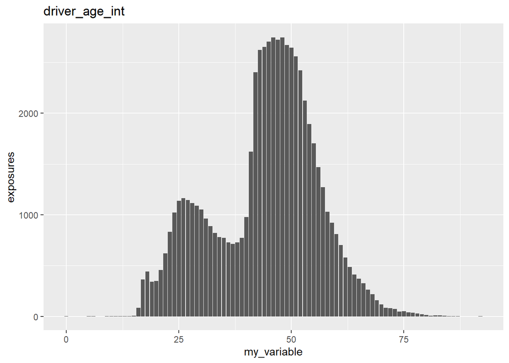

```r
e_summary("driver_age_int")
```

```r
dataOhlsson <- dataOhlsson %>%
  mutate(cap_age_int = case_when(as.double(driver_age_int) < 16 ~ 16,
                             as.double(driver_age_int) > 75 ~ 75,
                             TRUE ~ as.double(driver_age_int))) %>%
  mutate(transform_age_x1 = log(cap_age_int) - log(50)) %>%
  mutate(transform_age_x2 = transform_age_x1^2,
         transform_age_x3 = transform_age_x1^3)
```

### Gender

Male is most common. I want to use Male as the base.

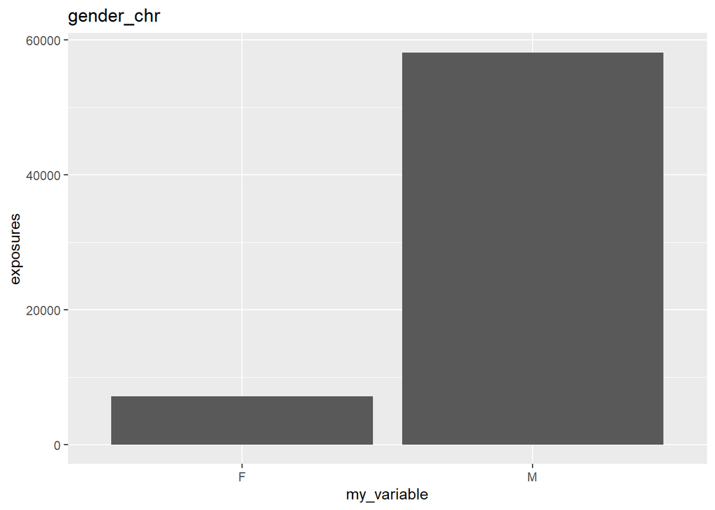

```r
e_summary("gender_chr")
```

```r
dataOhlsson <- dataOhlsson %>%
  mutate(gender_fctr = factor(gender_chr, levels = c("M","F")))
```

### Parish

Parish 4 is the most common. I want to use Parish 4 as the base

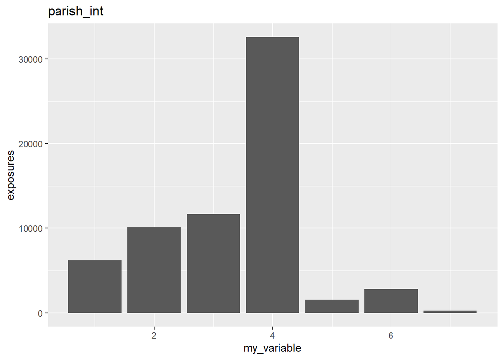

```r
e_summary("parish_int")
```

```r
dataOhlsson <- dataOhlsson %>%
  mutate(parish_fctr = factor(parish_int, levels = c(4,1,2,3,5,6,7)))
```

### EV_Ratio

The largest amount of exposures is at 3. I log the variable before modeling with it. I subtract log(3) so that 3 will be the base.

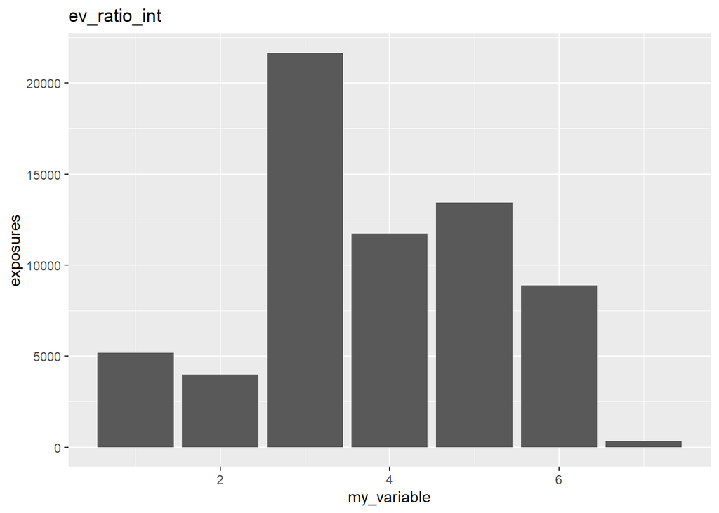

```r
e_summary("ev_ratio_int")
```

```r
dataOhlsson <- dataOhlsson %>%
  mutate(transform_ev_x1 = log(ev_ratio_int) - log(3)) %>%
  mutate(transform_ev_x2 = transform_ev_x1^2,
         transform_ev_x3 = transform_ev_x1^3)
```

### Vehicle_Age

The largest amount of exposures is near age 15. I will use age 15. I take the log before modeling with it. I can’t take the log of 0 so I add +1 to every value before logging.

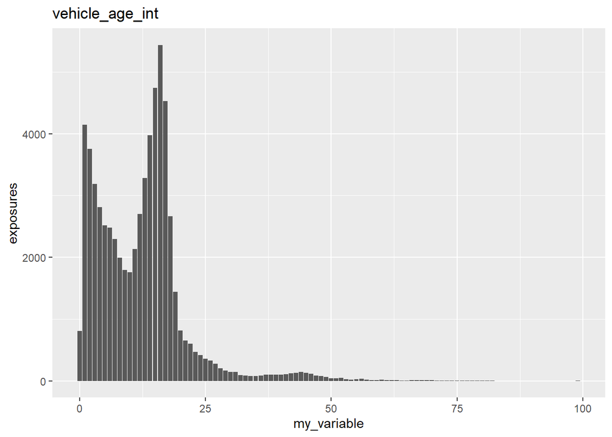

```r
e_summary("vehicle_age_int")
```

```r
dataOhlsson <- dataOhlsson %>%
  mutate(transform_veh_age_x1 = log(vehicle_age_int+1) - log(15+1)) %>%
  mutate(transform_veh_age_x2 = transform_veh_age_x1^2,
         transform_veh_age_x3 = transform_veh_age_x1^3)
```

### Claim_Free

Claim_Free code 7 is the most common. I want to use Claim_Free 7 as the base.

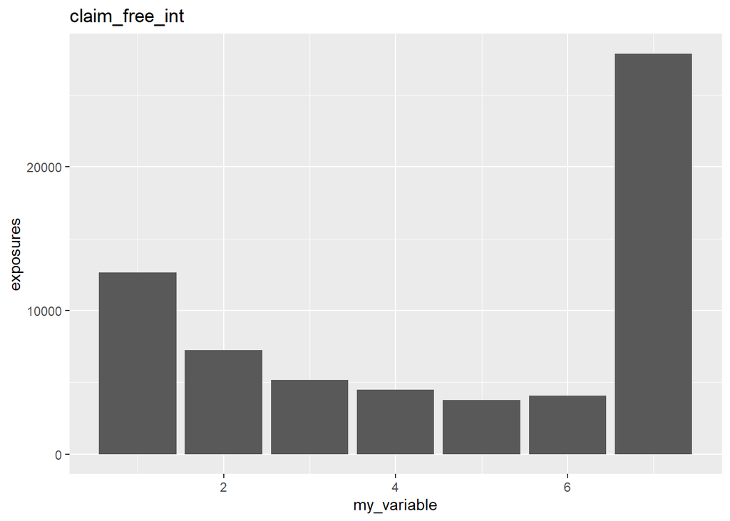

```r
e_summary("claim_free_int")
```

```r
dataOhlsson <- dataOhlsson %>%
  mutate(claim_free_fctr = factor(claim_free_int, levels = c(7,1,2,3,4,5,6)))
```

## Building GLM’s with Simple Factors

### Split into Train and Test

I take 40,000 rows of data for my training data. I will validate on the remaining 22181 rows.

```r
dataOhlsson_train <- slice_sample(dataOhlsson, n = 40000)
dataOhlsson_test <- dataOhlsson %>%
  filter(!(id %in% dataOhlsson_train$id))
```

### GLM1: Initial Test

```r
glm1 <- glm(claims ~ transform_age_x1 + transform_age_x2 + transform_age_x3 +
              gender_fctr + parish_fctr + transform_ev_x1 + transform_ev_x2 + transform_ev_x3 +
              transform_veh_age_x1 + transform_veh_age_x2 + transform_veh_age_x3 + claim_free_fctr,
                   family = poisson(link = "log"),
                   data = dataOhlsson_train,
                   offset = log(exposures))
dataOhlsson_train$fitted.values <- glm1$fitted.values

summary(glm1)
```

```
##
## Call:
## glm(formula = claims ~ transform_age_x1 + transform_age_x2 +
##     transform_age_x3 + gender_fctr + parish_fctr + transform_ev_x1 +
##     transform_ev_x2 + transform_ev_x3 + transform_veh_age_x1 +
##     transform_veh_age_x2 + transform_veh_age_x3 + claim_free_fctr,
##     family = poisson(link = "log"), data = dataOhlsson_train,
##     offset = log(exposures))
##
## Deviance Residuals:
##     Min       1Q   Median       3Q      Max
## -0.9722  -0.1547  -0.0965  -0.0621   4.3390
##
## Coefficients:
##                      Estimate Std. Error z value Pr(>|z|)
## (Intercept)          -6.22143    0.14470 -42.996  < 2e-16 ***
## transform_age_x1     -0.96182    0.40206  -2.392  0.01675 *
## transform_age_x2      4.81542    1.17536   4.097 4.19e-05 ***
## transform_age_x3      3.67274    0.93597   3.924 8.71e-05 ***
## gender_fctrF         -0.39854    0.16699  -2.387  0.01701 *
## parish_fctr1          1.46775    0.12648  11.605  < 2e-16 ***
## parish_fctr2          0.90480    0.12829   7.053 1.75e-12 ***
## parish_fctr3          0.30380    0.14451   2.102  0.03554 *
## parish_fctr5         -0.30085    0.41750  -0.721  0.47116
## parish_fctr6         -0.06724    0.32774  -0.205  0.83744
## parish_fctr7          0.02803    1.00401   0.028  0.97773
## transform_ev_x1      -0.30454    0.29351  -1.038  0.29946
## transform_ev_x2       1.28178    0.21942   5.842 5.17e-09 ***
## transform_ev_x3       1.18916    0.39971   2.975  0.00293 **
## transform_veh_age_x1 -0.87838    0.19833  -4.429 9.47e-06 ***
## transform_veh_age_x2 -0.35241    0.20645  -1.707  0.08783 .
## transform_veh_age_x3 -0.09444    0.05753  -1.641  0.10069
## claim_free_fctr1     -0.21853    0.14365  -1.521  0.12818
## claim_free_fctr2     -0.23230    0.16980  -1.368  0.17129
## claim_free_fctr3     -0.27249    0.19045  -1.431  0.15250
## claim_free_fctr4      0.04194    0.17525   0.239  0.81085
## claim_free_fctr5     -0.08354    0.19263  -0.434  0.66452
## claim_free_fctr6     -0.31304    0.21096  -1.484  0.13784
## ---
## Signif. codes:  0 '***' 0.001 '**' 0.01 '*' 0.05 '.' 0.1 ' ' 1
##
## (Dispersion parameter for poisson family taken to be 1)
##
##     Null deviance: 4433.5  on 39999  degrees of freedom
## Residual deviance: 3795.7  on 39977  degrees of freedom
## AIC: 4748
##
## Number of Fisher Scoring iterations: 8
```

Observations:

- Some Parishes appear significant, some do not
- Claim Free is not significant for any group
- It looks like only the 1 degree term is significant for vehicle age

### GLM2: Remove Claim Free and Vehicle Age x2, x3

I keep parishes for now. I remove Claim Free and the extra polynomials for vehicle age.

```r
glm2 <- glm(claims ~ transform_age_x1 + transform_age_x2 + transform_age_x3 +
              gender_fctr + parish_fctr + transform_ev_x1 + transform_ev_x2 + transform_ev_x3 +
              transform_veh_age_x1,
                   family = poisson(link = "log"),
                   data = dataOhlsson_train,
                   offset = log(exposures))
dataOhlsson_train$fitted.values <- glm2$fitted.values

summary(glm2)
```

```
##
## Call:
## glm(formula = claims ~ transform_age_x1 + transform_age_x2 +
##     transform_age_x3 + gender_fctr + parish_fctr + transform_ev_x1 +
##     transform_ev_x2 + transform_ev_x3 + transform_veh_age_x1,
##     family = poisson(link = "log"), data = dataOhlsson_train,
##     offset = log(exposures))
##
## Deviance Residuals:
##     Min       1Q   Median       3Q      Max
## -0.9963  -0.1552  -0.0981  -0.0641   4.3952
##
## Coefficients:
##                      Estimate Std. Error z value Pr(>|z|)
## (Intercept)          -6.36528    0.12979 -49.044  < 2e-16 ***
## transform_age_x1     -0.94946    0.40339  -2.354 0.018587 *
## transform_age_x2      4.66282    1.17039   3.984 6.78e-05 ***
## transform_age_x3      3.56809    0.92920   3.840 0.000123 ***
## gender_fctrF         -0.40295    0.16679  -2.416 0.015695 *
## parish_fctr1          1.46929    0.12642  11.622  < 2e-16 ***
## parish_fctr2          0.90623    0.12811   7.074 1.50e-12 ***
## parish_fctr3          0.30074    0.14450   2.081 0.037415 *
## parish_fctr5         -0.31144    0.41737  -0.746 0.455553
## parish_fctr6         -0.08745    0.32758  -0.267 0.789502
## parish_fctr7          0.02234    1.00379   0.022 0.982247
## transform_ev_x1      -0.24080    0.29142  -0.826 0.408636
## transform_ev_x2       1.33054    0.21609   6.157 7.40e-10 ***
## transform_ev_x3       1.22584    0.39715   3.087 0.002025 **
## transform_veh_age_x1 -0.61505    0.05438 -11.311  < 2e-16 ***
## ---
## Signif. codes:  0 '***' 0.001 '**' 0.01 '*' 0.05 '.' 0.1 ' ' 1
##
## (Dispersion parameter for poisson family taken to be 1)
##
##     Null deviance: 4433.5  on 39999  degrees of freedom
## Residual deviance: 3805.1  on 39985  degrees of freedom
## AIC: 4741.4
##
## Number of Fisher Scoring iterations: 8
```

I want to visualize how well my model fits the data by variable. I create a function to help me look at this.

```r
one_way_plot <- function(varname){

  summary <- dataOhlsson_train %>%
    group_by_at(varname) %>%
    summarize(actual = sum(claims)/sum(exposures),
              fitted = sum(fitted.values)/sum(exposures),
              exposures = sum(exposures),
              .groups = 'drop') %>%
    ungroup()
  names(summary)[1]<-"my_variable"

  actual_fitted_plot <- ggplot(data = summary) +
    geom_point(aes(x = my_variable, y = actual),col = "black",shape=4) +
    geom_point(aes(x = my_variable, y = fitted),col = "blue",shape = 1) +
    ggtitle(varname) +
    ylim(c(0,.08))

  expo_plot <- ggplot(data = summary) +
    geom_col(aes(x = my_variable, y = exposures)) +
    ggtitle(varname)

  plot_grid(actual_fitted_plot, expo_plot, labels = "AUTO")
}
```

Let’s look at driver age.

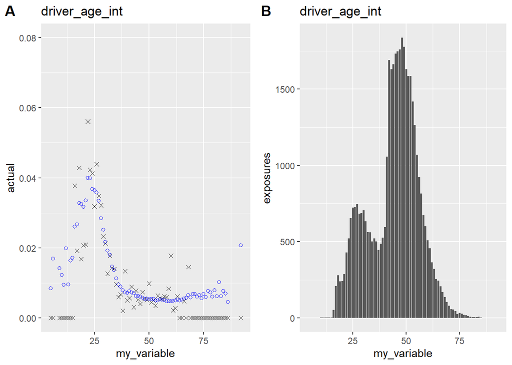

```r
one_way_plot("driver_age_int")
```

Let’s look at the indicated driver age factors from this approach.

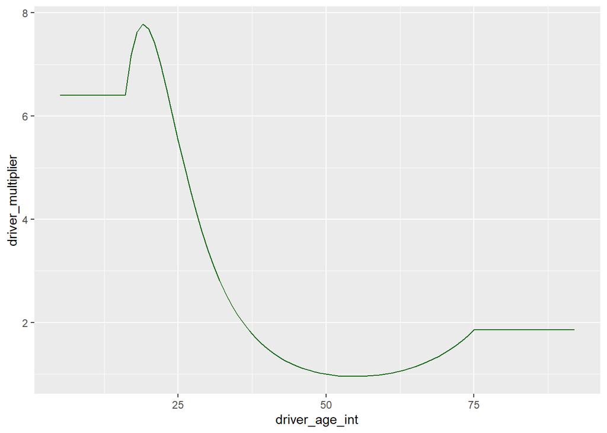

```r
drvr_age_beta1 <- glm2$coefficients[2]
drvr_age_beta2 <- glm2$coefficients[3]
drvr_age_beta3 <- glm2$coefficients[4]

multiplier <- dataOhlsson_train %>%
  mutate(driver_multiplier = exp(drvr_age_beta1*transform_age_x1)*exp(drvr_age_beta2*transform_age_x2)*exp(drvr_age_beta3*transform_age_x3)) %>%
  select(driver_age_int, driver_multiplier) %>%
  arrange(driver_age_int) %>%
  distinct()

ggplot(multiplier) +
  geom_line(aes(x=driver_age_int,y=driver_multiplier),col="dark green")
```

I don’t like this. The factor increases after 16 and then quickly decreases again. I try again with a 2 degree curve.

### GLM3: Driver Age 2 Degree Curve

```r
glm3 <- glm(claims ~ transform_age_x1 + transform_age_x2 +
              gender_fctr + parish_fctr + transform_ev_x1 + transform_ev_x2 + transform_ev_x3 +
              transform_veh_age_x1,
                   family = poisson(link = "log"),
                   data = dataOhlsson_train,
                   offset = log(exposures))
dataOhlsson_train$fitted.values <- glm3$fitted.values

summary(glm3)
```

```
##
## Call:
## glm(formula = claims ~ transform_age_x1 + transform_age_x2 +
##     gender_fctr + parish_fctr + transform_ev_x1 + transform_ev_x2 +
##     transform_ev_x3 + transform_veh_age_x1, family = poisson(link = "log"),
##     data = dataOhlsson_train, offset = log(exposures))
##
## Deviance Residuals:
##     Min       1Q   Median       3Q      Max
## -0.9584  -0.1553  -0.0976  -0.0623   4.3221
##
## Coefficients:
##                      Estimate Std. Error z value Pr(>|z|)
## (Intercept)          -6.30719    0.12883 -48.956  < 2e-16 ***
## transform_age_x1     -1.94331    0.37370  -5.200 1.99e-07 ***
## transform_age_x2      0.24197    0.42334   0.572  0.56761
## gender_fctrF         -0.39103    0.16676  -2.345  0.01903 *
## parish_fctr1          1.50643    0.12609  11.947  < 2e-16 ***
## parish_fctr2          0.92846    0.12799   7.254 4.05e-13 ***
## parish_fctr3          0.32479    0.14439   2.249  0.02448 *
## parish_fctr5         -0.27398    0.41727  -0.657  0.51144
## parish_fctr6         -0.07787    0.32757  -0.238  0.81210
## parish_fctr7          0.02728    1.00378   0.027  0.97832
## transform_ev_x1      -0.15410    0.29343  -0.525  0.59946
## transform_ev_x2       1.32691    0.21716   6.110 9.95e-10 ***
## transform_ev_x3       1.21117    0.39929   3.033  0.00242 **
## transform_veh_age_x1 -0.62083    0.05444 -11.405  < 2e-16 ***
## ---
## Signif. codes:  0 '***' 0.001 '**' 0.01 '*' 0.05 '.' 0.1 ' ' 1
##
## (Dispersion parameter for poisson family taken to be 1)
##
##     Null deviance: 4433.5  on 39999  degrees of freedom
## Residual deviance: 3819.2  on 39986  degrees of freedom
## AIC: 4753.5
##
## Number of Fisher Scoring iterations: 8
```

The 2nd degree polynomial term for age is no longer significant. I take it out.

### GLM4: Driver Age 1 Degree Curve

```r
glm4 <- glm(claims ~ transform_age_x1 +
              gender_fctr + parish_fctr + transform_ev_x1 + transform_ev_x2 + transform_ev_x3 +
              transform_veh_age_x1,
                   family = poisson(link = "log"),
                   data = dataOhlsson_train,
                   offset = log(exposures))
dataOhlsson_train$fitted.values <- glm4$fitted.values

summary(glm4)
```

```
##
## Call:
## glm(formula = claims ~ transform_age_x1 + gender_fctr + parish_fctr +
##     transform_ev_x1 + transform_ev_x2 + transform_ev_x3 + transform_veh_age_x1,
##     family = poisson(link = "log"), data = dataOhlsson_train,
##     offset = log(exposures))
##
## Deviance Residuals:
##     Min       1Q   Median       3Q      Max
## -0.9558  -0.1556  -0.0975  -0.0622   4.3262
##
## Coefficients:
##                      Estimate Std. Error z value Pr(>|z|)
## (Intercept)          -6.30769    0.12896 -48.913  < 2e-16 ***
## transform_age_x1     -2.14276    0.13526 -15.841  < 2e-16 ***
## gender_fctrF         -0.39948    0.16610  -2.405  0.01617 *
## parish_fctr1          1.49447    0.12432  12.021  < 2e-16 ***
## parish_fctr2          0.92333    0.12768   7.232 4.77e-13 ***
## parish_fctr3          0.32083    0.14422   2.225  0.02610 *
## parish_fctr5         -0.27937    0.41716  -0.670  0.50305
## parish_fctr6         -0.07932    0.32756  -0.242  0.80867
## parish_fctr7          0.02602    1.00378   0.026  0.97932
## transform_ev_x1      -0.17806    0.29023  -0.614  0.53954
## transform_ev_x2       1.32958    0.21698   6.128 8.92e-10 ***
## transform_ev_x3       1.21951    0.39894   3.057  0.00224 **
## transform_veh_age_x1 -0.62011    0.05434 -11.411  < 2e-16 ***
## ---
## Signif. codes:  0 '***' 0.001 '**' 0.01 '*' 0.05 '.' 0.1 ' ' 1
##
## (Dispersion parameter for poisson family taken to be 1)
##
##     Null deviance: 4433.5  on 39999  degrees of freedom
## Residual deviance: 3819.5  on 39987  degrees of freedom
## AIC: 4751.8
##
## Number of Fisher Scoring iterations: 8
```

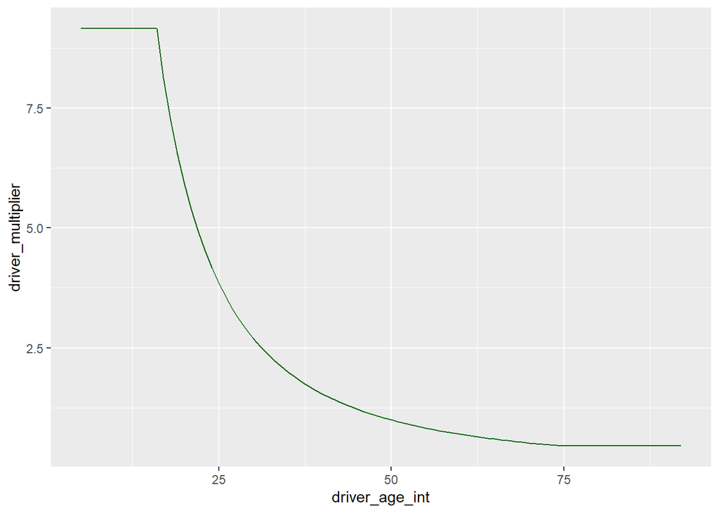

```r
drvr_age_beta1 <- glm3$coefficients[2]

multiplier <- dataOhlsson_train %>%
  mutate(driver_multiplier = exp(drvr_age_beta1*transform_age_x1)) %>%
  select(driver_age_int, driver_multiplier) %>%
  arrange(driver_age_int) %>%
  distinct()

ggplot(multiplier) +
  geom_line(aes(x=driver_age_int,y=driver_multiplier),col="dark green")
```

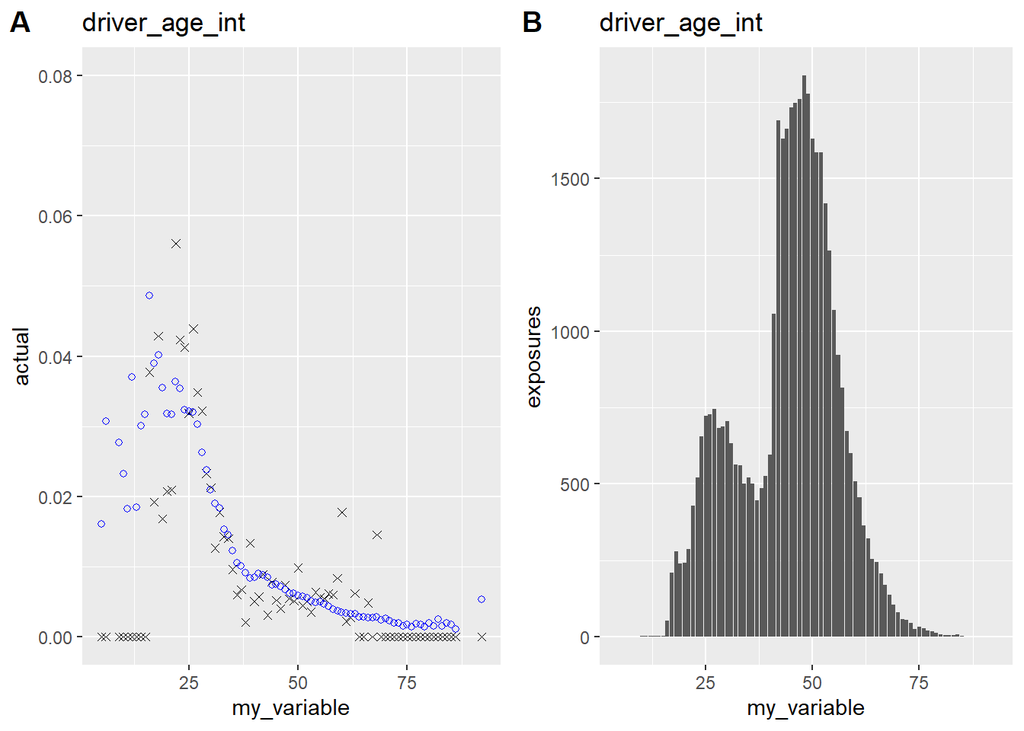

```r
one_way_plot("driver_age_int")
```

## Parish

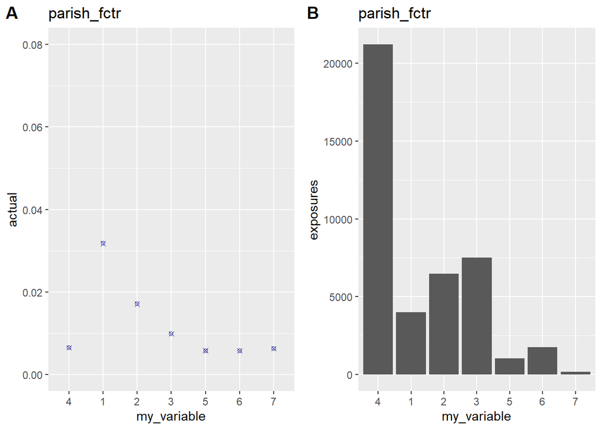

```r
one_way_plot("parish_fctr")
```

```r
exp(glm4$coefficients[4:9])
```

```
## parish_fctr1 parish_fctr2 parish_fctr3 parish_fctr5 parish_fctr6 parish_fctr7
##    4.4569678    2.5176478    1.3782775    0.7562569    0.9237472    1.0263647
```

```r
summary(glm4)
```

```
##
## Call:
## glm(formula = claims ~ transform_age_x1 + gender_fctr + parish_fctr +
##     transform_ev_x1 + transform_ev_x2 + transform_ev_x3 + transform_veh_age_x1,
##     family = poisson(link = "log"), data = dataOhlsson_train,
##     offset = log(exposures))
##
## Deviance Residuals:
##     Min       1Q   Median       3Q      Max
## -0.9558  -0.1556  -0.0975  -0.0622   4.3262
##
## Coefficients:
##                      Estimate Std. Error z value Pr(>|z|)
## (Intercept)          -6.30769    0.12896 -48.913  < 2e-16 ***
## transform_age_x1     -2.14276    0.13526 -15.841  < 2e-16 ***
## gender_fctrF         -0.39948    0.16610  -2.405  0.01617 *
## parish_fctr1          1.49447    0.12432  12.021  < 2e-16 ***
## parish_fctr2          0.92333    0.12768   7.232 4.77e-13 ***
## parish_fctr3          0.32083    0.14422   2.225  0.02610 *
## parish_fctr5         -0.27937    0.41716  -0.670  0.50305
## parish_fctr6         -0.07932    0.32756  -0.242  0.80867
## parish_fctr7          0.02602    1.00378   0.026  0.97932
## transform_ev_x1      -0.17806    0.29023  -0.614  0.53954
## transform_ev_x2       1.32958    0.21698   6.128 8.92e-10 ***
## transform_ev_x3       1.21951    0.39894   3.057  0.00224 **
## transform_veh_age_x1 -0.62011    0.05434 -11.411  < 2e-16 ***
## ---
## Signif. codes:  0 '***' 0.001 '**' 0.01 '*' 0.05 '.' 0.1 ' ' 1
##
## (Dispersion parameter for poisson family taken to be 1)
##
##     Null deviance: 4433.5  on 39999  degrees of freedom
## Residual deviance: 3819.5  on 39987  degrees of freedom
## AIC: 4751.8
##
## Number of Fisher Scoring iterations: 8
```

Parishes 5, 6, 7 have low exposures and the observed frequencies are similar. I am going to group them.

### GLM5: Parish Binned

```r
dataOhlsson_train <- dataOhlsson_train %>%
  mutate(parish_bin_fctr = case_when(as.double(parish_fctr)>4 ~ "5-7",
                                  as.double(parish_fctr)<5 ~ as.character(parish_fctr))) %>%
  mutate(parish_bin_fctr = factor(parish_bin_fctr, levels = c("4","1","2","3","5-7")))

glm5 <- glm(claims ~ transform_age_x1 +
              gender_fctr + parish_bin_fctr + transform_ev_x1 + transform_ev_x2 + transform_ev_x3 +
              transform_veh_age_x1,
                   family = poisson(link = "log"),
                   data = dataOhlsson_train,
                   offset = log(exposures))
dataOhlsson_train$fitted.values <- glm5$fitted.values

summary(glm5)
```

```
##
## Call:
## glm(formula = claims ~ transform_age_x1 + gender_fctr + parish_bin_fctr +
##     transform_ev_x1 + transform_ev_x2 + transform_ev_x3 + transform_veh_age_x1,
##     family = poisson(link = "log"), data = dataOhlsson_train,
##     offset = log(exposures))
##
## Deviance Residuals:
##     Min       1Q   Median       3Q      Max
## -0.9558  -0.1556  -0.0975  -0.0621   4.3261
##
## Coefficients:
##                      Estimate Std. Error z value Pr(>|z|)
## (Intercept)          -6.30703    0.12893 -48.918  < 2e-16 ***
## transform_age_x1     -2.14198    0.13526 -15.836  < 2e-16 ***
## gender_fctrF         -0.40026    0.16608  -2.410  0.01595 *
## parish_bin_fctr1      1.49457    0.12432  12.022  < 2e-16 ***
## parish_bin_fctr2      0.92335    0.12768   7.232 4.76e-13 ***
## parish_bin_fctr3      0.32089    0.14422   2.225  0.02608 *
## parish_bin_fctr5-7   -0.14910    0.25710  -0.580  0.56196
## transform_ev_x1      -0.17928    0.29020  -0.618  0.53673
## transform_ev_x2       1.33048    0.21699   6.131 8.71e-10 ***
## transform_ev_x3       1.22068    0.39895   3.060  0.00222 **
## transform_veh_age_x1 -0.61974    0.05434 -11.406  < 2e-16 ***
## ---
## Signif. codes:  0 '***' 0.001 '**' 0.01 '*' 0.05 '.' 0.1 ' ' 1
##
## (Dispersion parameter for poisson family taken to be 1)
##
##     Null deviance: 4433.5  on 39999  degrees of freedom
## Residual deviance: 3819.7  on 39989  degrees of freedom
## AIC: 4748
##
## Number of Fisher Scoring iterations: 8
```

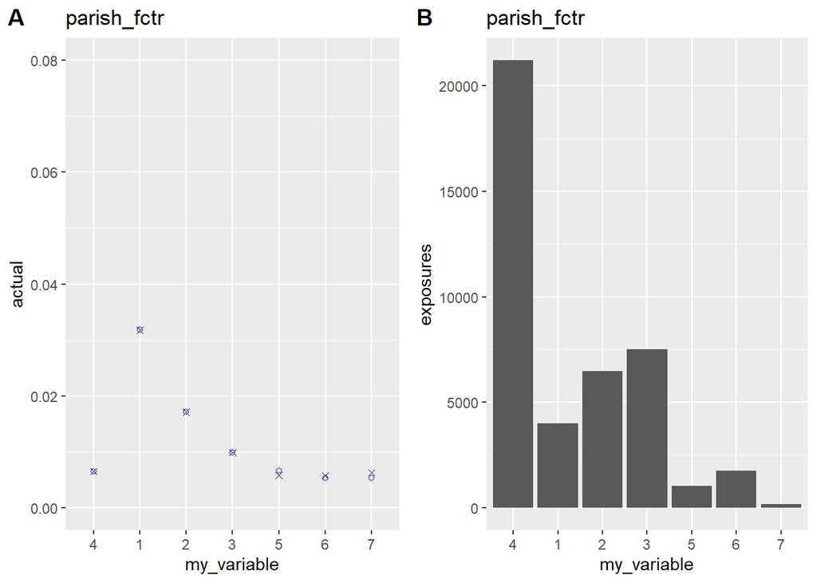

```r
one_way_plot("parish_fctr")
```

```r
exp(glm5$coefficients[4:7])
```

```
##   parish_bin_fctr1   parish_bin_fctr2   parish_bin_fctr3 parish_bin_fctr5-7
##          4.4574256          2.5177208          1.3783569          0.8614825
```

## EV_Ratio

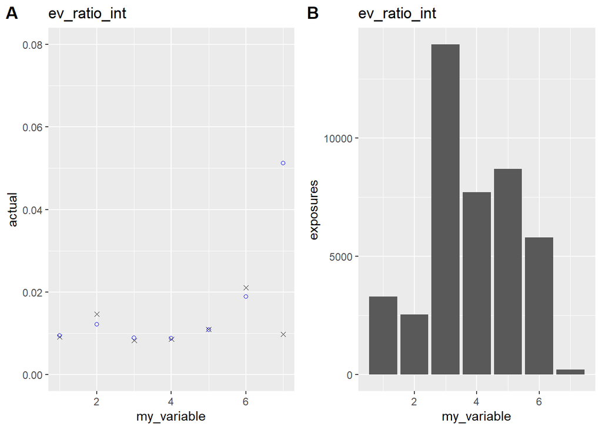

```r
one_way_plot("ev_ratio_int")
```

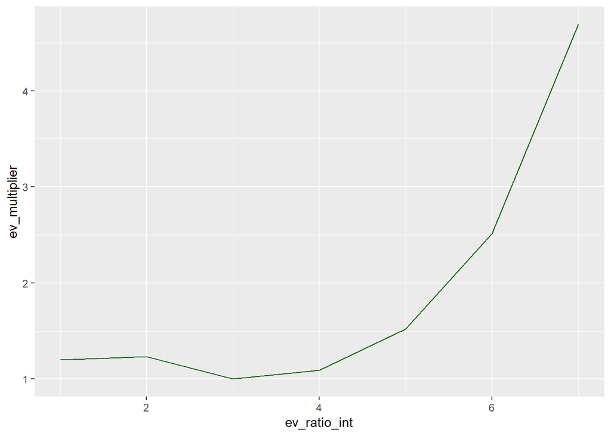

```r
ev_beta1 <- glm5$coefficients[8]
ev_beta2 <- glm5$coefficients[9]
ev_beta3 <- glm5$coefficients[10]

multiplier <- dataOhlsson_train %>%
  mutate(ev_multiplier = exp(ev_beta1*transform_ev_x1)*exp(ev_beta2*transform_ev_x2)*exp(ev_beta3*transform_ev_x3)) %>%
  select(ev_ratio_int, ev_multiplier) %>%
  arrange(ev_ratio_int) %>%
  distinct()

ggplot(multiplier) +
  geom_line(aes(x=ev_ratio_int,y=ev_multiplier),col="dark green")
```

There are some reversals in how I thought the multiplier would look. I am going to look at what happens when I model each EV Ratio as it’s own factor.

### GLM6: Engine Vehicle Ratio Categorical

```r
dataOhlsson_train <- dataOhlsson_train %>%
  mutate(ev_ratio_fctr = as.character(ev_ratio_int)) %>%
  mutate(ev_ratio_fctr = factor(ev_ratio_fctr, levels = c("3","1","2","4","5","6","7")))

glm6 <- glm(claims ~ transform_age_x1 +
              gender_fctr + parish_bin_fctr + ev_ratio_fctr +
              transform_veh_age_x1,
                   family = poisson(link = "log"),
                   data = dataOhlsson_train,
                   offset = log(exposures))
dataOhlsson_train$fitted.values <- glm6$fitted.values

summary(glm6)
```

```
##
## Call:
## glm(formula = claims ~ transform_age_x1 + gender_fctr + parish_bin_fctr +
##     ev_ratio_fctr + transform_veh_age_x1, family = poisson(link = "log"),
##     data = dataOhlsson_train, offset = log(exposures))
##
## Deviance Residuals:
##     Min       1Q   Median       3Q      Max
## -1.0131  -0.1539  -0.0962  -0.0613   4.3222
##
## Coefficients:
##                      Estimate Std. Error z value Pr(>|z|)
## (Intercept)          -6.39771    0.14301 -44.735  < 2e-16 ***
## transform_age_x1     -2.13975    0.13557 -15.783  < 2e-16 ***
## gender_fctrF         -0.39318    0.16610  -2.367 0.017929 *
## parish_bin_fctr1      1.50101    0.12433  12.073  < 2e-16 ***
## parish_bin_fctr2      0.92443    0.12768   7.240 4.49e-13 ***
## parish_bin_fctr3      0.32221    0.14422   2.234 0.025476 *
## parish_bin_fctr5-7   -0.16483    0.25714  -0.641 0.521519
## ev_ratio_fctr1        0.23419    0.20965   1.117 0.263963
## ev_ratio_fctr2        0.47499    0.19103   2.487 0.012900 *
## ev_ratio_fctr4        0.13370    0.15495   0.863 0.388193
## ev_ratio_fctr5        0.50468    0.14022   3.599 0.000319 ***
## ev_ratio_fctr6        1.11177    0.13295   8.363  < 2e-16 ***
## ev_ratio_fctr7       -0.03964    0.71400  -0.056 0.955721
## transform_veh_age_x1 -0.63400    0.05452 -11.629  < 2e-16 ***
## ---
## Signif. codes:  0 '***' 0.001 '**' 0.01 '*' 0.05 '.' 0.1 ' ' 1
##
## (Dispersion parameter for poisson family taken to be 1)
##
##     Null deviance: 4433.5  on 39999  degrees of freedom
## Residual deviance: 3805.8  on 39986  degrees of freedom
## AIC: 4740.1
##
## Number of Fisher Scoring iterations: 8
```

The betas 1 - 4 move up and down. The beta for 5 is higher than each of them in 1-4. The beta is largest for 6. The data is extremely thin in 7.

I will bin them in “1-4”, “5”, and “6-7”

```r
dataOhlsson_train <- dataOhlsson_train %>%
  mutate(ev_ratio_fctr = as.numeric(ev_ratio_fctr)) %>%
  mutate(ev_ratio_bin_fctr = case_when(ev_ratio_fctr < 5 ~ "1-4",
                                    ev_ratio_fctr == 5 ~ "5",
                                    ev_ratio_fctr > 5 ~ "6-7")) %>%
  mutate(ev_ratio_bin_fctr = factor(ev_ratio_bin_fctr, levels = c("1-4","5","6-7")))

glm7 <- glm(claims ~ transform_age_x1 +
              gender_fctr + parish_bin_fctr + ev_ratio_bin_fctr +
              transform_veh_age_x1,
                   family = poisson(link = "log"),
                   data = dataOhlsson_train,
                   offset = log(exposures))
dataOhlsson_train$fitted.values <- glm7$fitted.values

summary(glm7)
```

```
##
## Call:
## glm(formula = claims ~ transform_age_x1 + gender_fctr + parish_bin_fctr +
##     ev_ratio_bin_fctr + transform_veh_age_x1, family = poisson(link = "log"),
##     data = dataOhlsson_train, offset = log(exposures))
##
## Deviance Residuals:
##     Min       1Q   Median       3Q      Max
## -0.9874  -0.1551  -0.0964  -0.0609   4.3281
##
## Coefficients:
##                      Estimate Std. Error z value Pr(>|z|)
## (Intercept)          -6.27549    0.12509 -50.168  < 2e-16 ***
## transform_age_x1     -2.18054    0.13414 -16.256  < 2e-16 ***
## gender_fctrF         -0.40147    0.16594  -2.419  0.01555 *
## parish_bin_fctr1      1.49445    0.12427  12.026  < 2e-16 ***
## parish_bin_fctr2      0.92393    0.12768   7.237  4.6e-13 ***
## parish_bin_fctr3      0.32036    0.14421   2.221  0.02632 *
## parish_bin_fctr5-7   -0.15469    0.25713  -0.602  0.54745
## ev_ratio_bin_fctr5    0.37985    0.12138   3.129  0.00175 **
## ev_ratio_bin_fctr6-7  0.95085    0.11179   8.506  < 2e-16 ***
## transform_veh_age_x1 -0.62033    0.05417 -11.452  < 2e-16 ***
## ---
## Signif. codes:  0 '***' 0.001 '**' 0.01 '*' 0.05 '.' 0.1 ' ' 1
##
## (Dispersion parameter for poisson family taken to be 1)
##
##     Null deviance: 4433.5  on 39999  degrees of freedom
## Residual deviance: 3815.8  on 39990  degrees of freedom
## AIC: 4742.1
##
## Number of Fisher Scoring iterations: 8
```

```r
exp(glm7$coefficients[8:9])
```

```
##   ev_ratio_bin_fctr5 ev_ratio_bin_fctr6-7
##             1.462059             2.587913
```

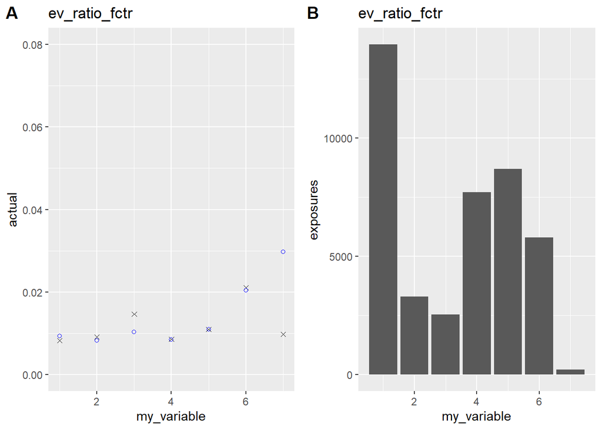

```r
one_way_plot("ev_ratio_fctr")
```

## Vehicle Age

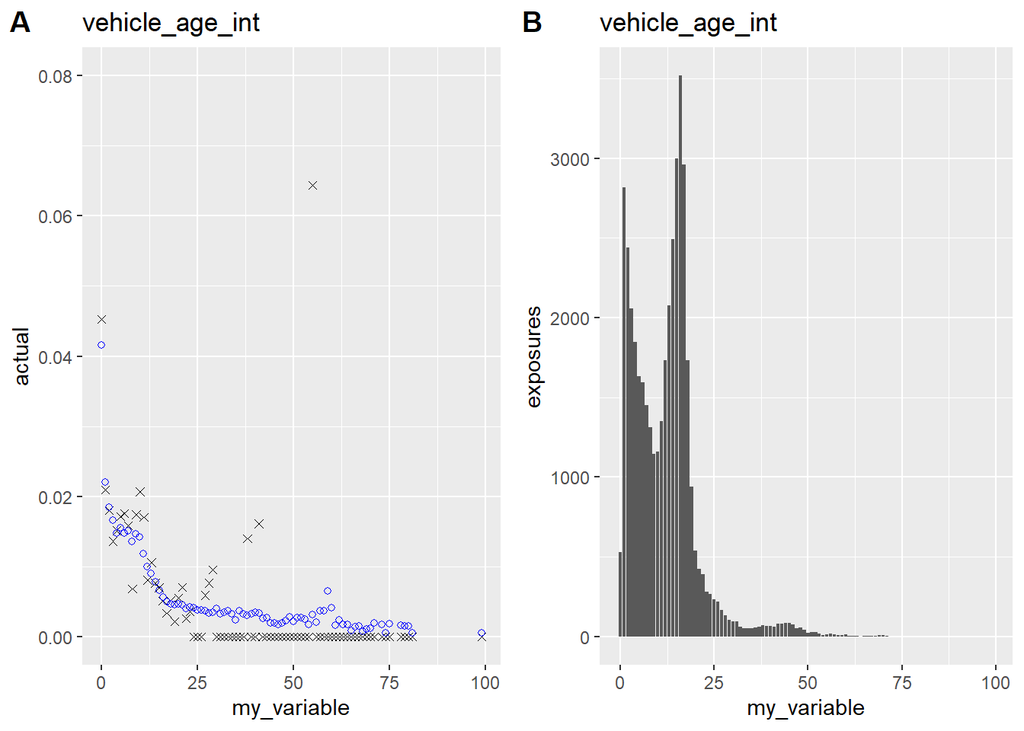

```r
one_way_plot("vehicle_age_int")
```

There isn’t a lot of exposures past 25 I will cap the x values at 25

### Final GLM Simple

```r
dataOhlsson_train <- dataOhlsson_train %>%
  mutate(vehicle_age_cap_int = if_else(vehicle_age_int > 25, as.double(25), as.double(vehicle_age_int))) %>%
  mutate(transform_veh_age_x1 = log(vehicle_age_cap_int+1) - log(15+1))

glm_simple <- glm(claims ~ transform_age_x1 +
              gender_fctr + parish_bin_fctr + ev_ratio_bin_fctr +
              transform_veh_age_x1,
                   family = poisson(link = "log"),
                   data = dataOhlsson_train,
                   offset = log(exposures))
dataOhlsson_train$fitted.values <- glm_simple$fitted.values

summary(glm_simple)
```

```
##
## Call:
## glm(formula = claims ~ transform_age_x1 + gender_fctr + parish_bin_fctr +
##     ev_ratio_bin_fctr + transform_veh_age_x1, family = poisson(link = "log"),
##     data = dataOhlsson_train, offset = log(exposures))
##
## Deviance Residuals:
##     Min       1Q   Median       3Q      Max
## -0.9909  -0.1549  -0.0965  -0.0613   4.3287
##
## Coefficients:
##                      Estimate Std. Error z value Pr(>|z|)
## (Intercept)          -6.28923    0.12535 -50.174  < 2e-16 ***
## transform_age_x1     -2.18330    0.13422 -16.267  < 2e-16 ***
## gender_fctrF         -0.39892    0.16593  -2.404  0.01621 *
## parish_bin_fctr1      1.49346    0.12427  12.018  < 2e-16 ***
## parish_bin_fctr2      0.92391    0.12767   7.236 4.61e-13 ***
## parish_bin_fctr3      0.32043    0.14422   2.222  0.02629 *
## parish_bin_fctr5-7   -0.15615    0.25713  -0.607  0.54366
## ev_ratio_bin_fctr5    0.38695    0.12138   3.188  0.00143 **
## ev_ratio_bin_fctr6-7  0.95776    0.11179   8.567  < 2e-16 ***
## transform_veh_age_x1 -0.62682    0.05455 -11.490  < 2e-16 ***
## ---
## Signif. codes:  0 '***' 0.001 '**' 0.01 '*' 0.05 '.' 0.1 ' ' 1
##
## (Dispersion parameter for poisson family taken to be 1)
##
##     Null deviance: 4433.5  on 39999  degrees of freedom
## Residual deviance: 3816.6  on 39990  degrees of freedom
## AIC: 4742.9
##
## Number of Fisher Scoring iterations: 8
```

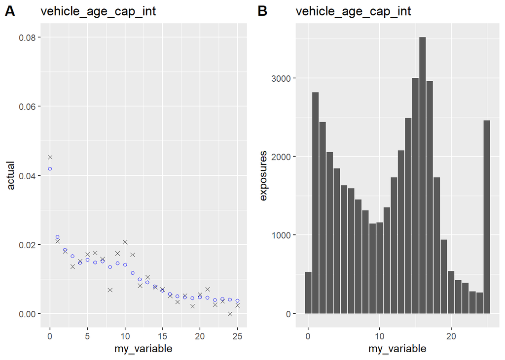

```r
one_way_plot("vehicle_age_cap_int")
```

## Look at the One Way Plots again

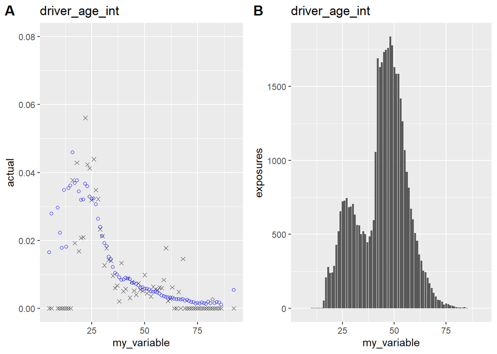

```r
one_way_plot("driver_age_int")
```

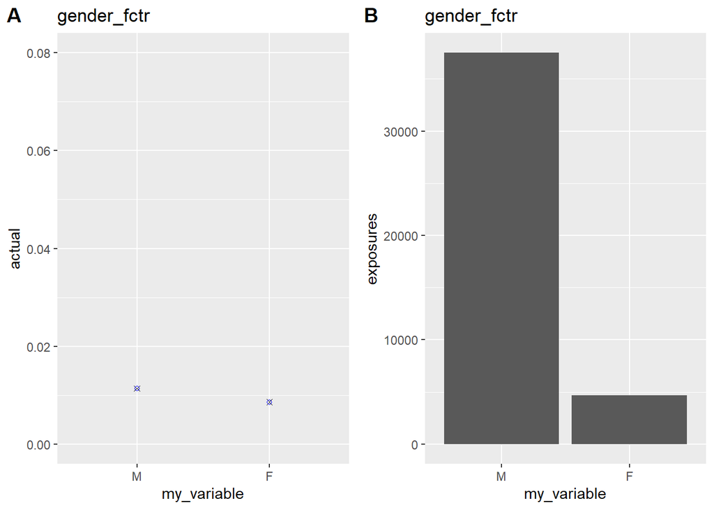

```r
one_way_plot("gender_fctr")
```

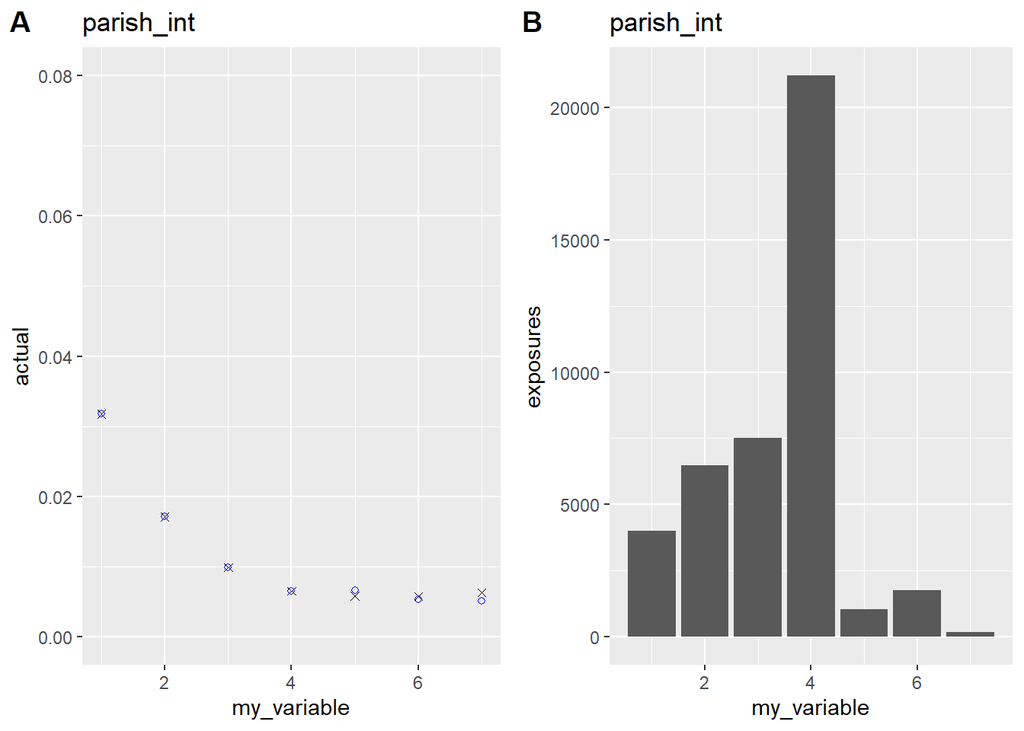

```r
one_way_plot("parish_int")
```

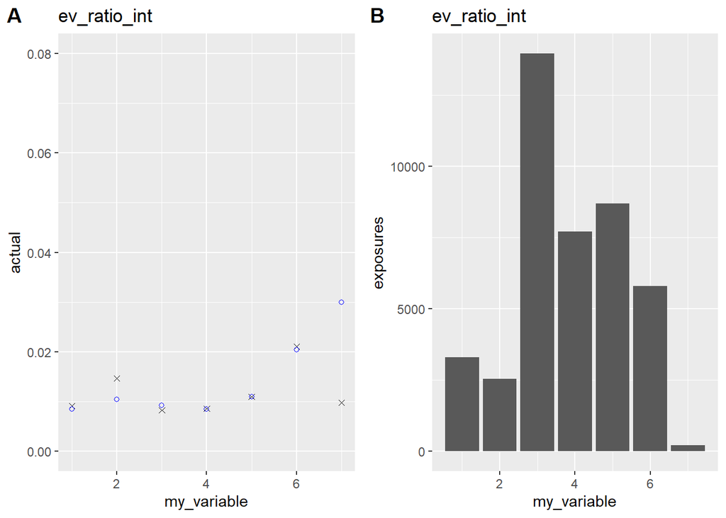

```r
one_way_plot("ev_ratio_int")
```

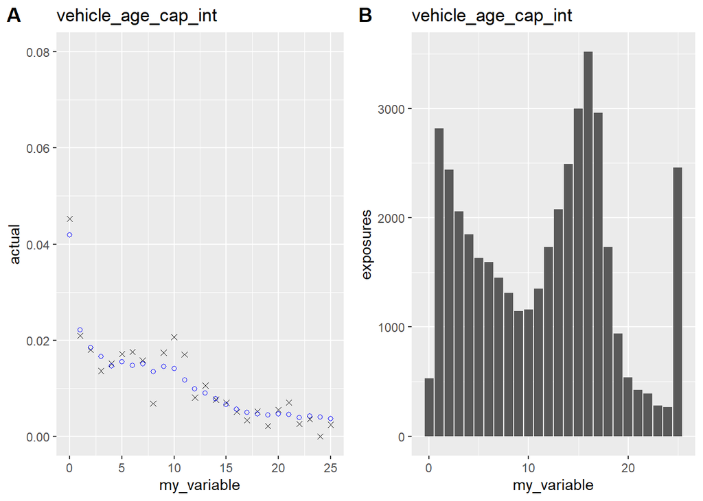

```r
one_way_plot("vehicle_age_cap_int")
```

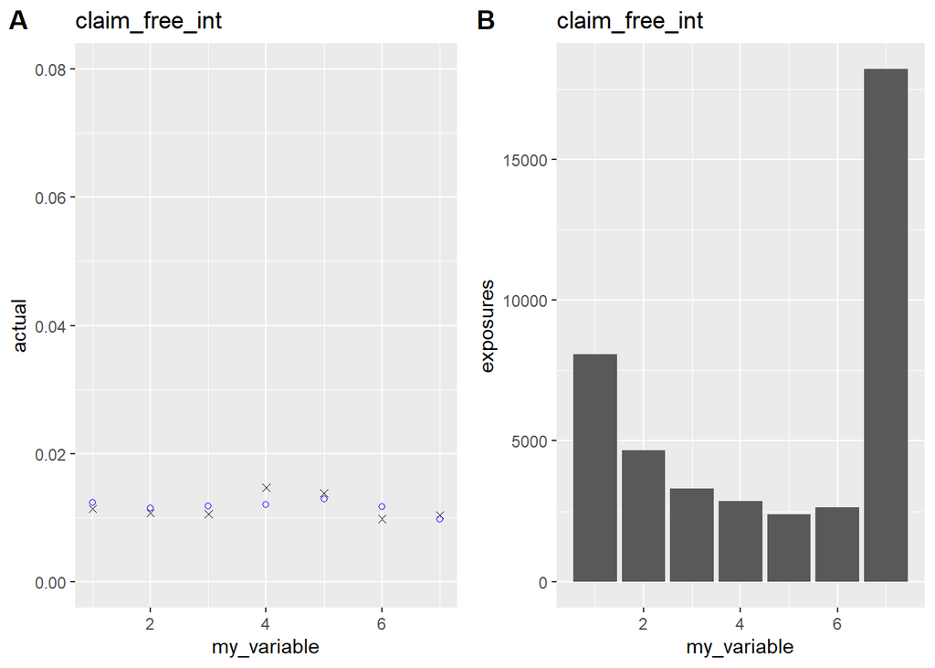

```r
one_way_plot("claim_free_int")
```

## Adding an Interaction Term

Create a two-way plot function

```r
two_way_plot <- function(variable1, variable2, predictions1, claims1, exposures1){
  table <- data.frame(variable1 = variable1,
                     variable2 = variable2,
                     predictions = predictions1,
                     claims = claims1,
                     exposures = exposures1)
  total_expos <- sum(table$exposures)

  table2 <- table %>%
    group_by(variable1, variable2) %>%
    summarize(obs_freq = sum(claims)/sum(exposures),
              fit_freq = sum(predictions)/sum(exposures),
              exposures = sum(exposures),
              .groups = 'drop') %>%
    ungroup()

  ggplot(data = table2) +
    geom_point(aes(x = variable1, y = obs_freq), col = "black", shape = 4) +
    geom_point(aes(x = variable1, y = fit_freq), col = "blue", shape = 1) +
    ylim(0,0.1) +
    facet_wrap(~ variable2)

}
```

Check our fit on driver age by gender

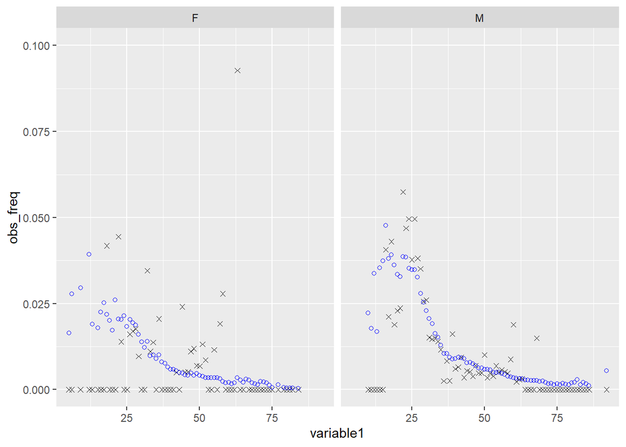

```r
two_way_plot(dataOhlsson_train$driver_age_int,
        dataOhlsson_train$gender_chr,
        dataOhlsson_train$fitted.values,
        dataOhlsson_train$claims,
        dataOhlsson_train$exposures)
```

It’s a little hard to see what is going because the ages are so granular. We bin the ages and then look at the two way plot again.

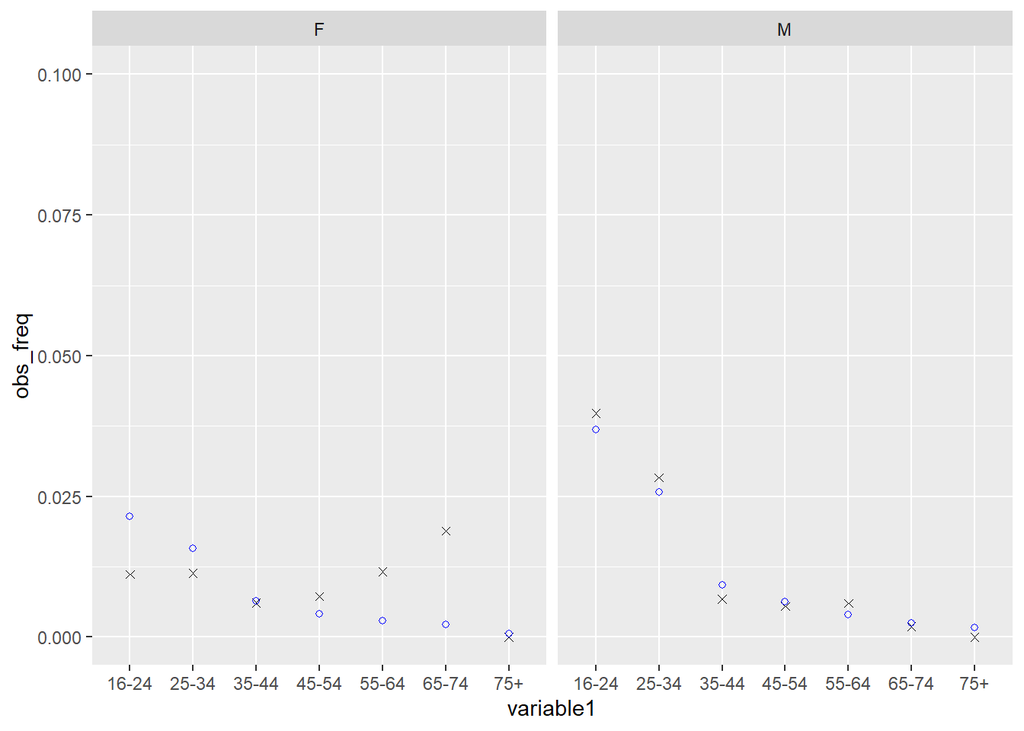

```r
dataOhlsson_train <- dataOhlsson_train %>%
  mutate(driver_age_bin_chr = case_when(driver_age_int < 25 ~ "16-24",
                             driver_age_int >= 25 & driver_age_int < 35 ~ "25-34",
                             driver_age_int >= 35 & driver_age_int < 45 ~ "35-44",
                             driver_age_int >= 45 & driver_age_int < 55 ~ "45-54",
                             driver_age_int >= 55 & driver_age_int < 65 ~ "55-64",
                             driver_age_int >= 65 & driver_age_int < 75 ~ "65-74",
                             driver_age_int >= 75 ~ "75+"))

two_way_plot(dataOhlsson_train$driver_age_bin_chr,
        dataOhlsson_train$gender_chr,
        dataOhlsson_train$fitted.values,
        dataOhlsson_train$claims,
        dataOhlsson_train$exposures)
```

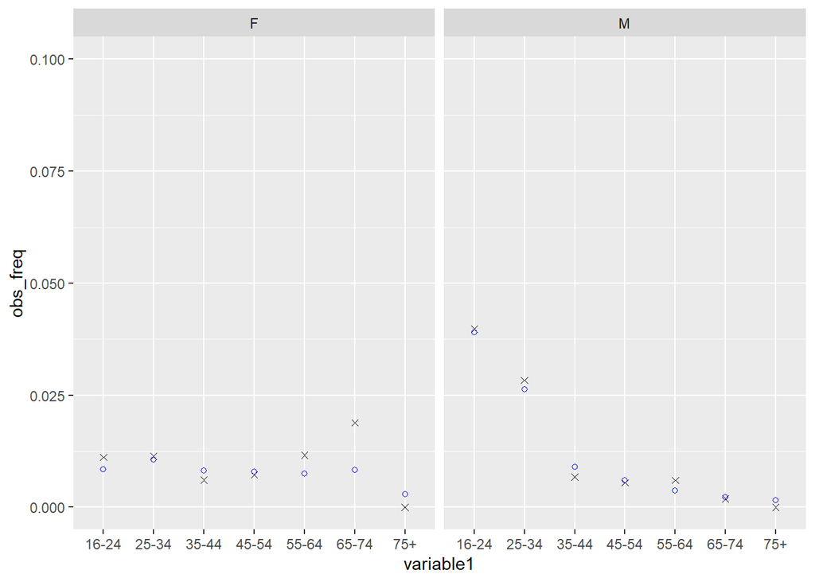

```r
glm_interaction <- glm(claims ~ transform_age_x1 +
                         gender_fctr + parish_bin_fctr + ev_ratio_bin_fctr +
                         transform_veh_age_x1 + gender_fctr*transform_age_x1,
            family = poisson(link = "log"),
            data = dataOhlsson_train,
            offset = log(exposures))
dataOhlsson_train$glm_int_fitted_values <- glm_interaction$fitted.values

two_way_plot(dataOhlsson_train$driver_age_bin_chr,
        dataOhlsson_train$gender_chr,
        dataOhlsson_train$glm_int_fitted_values,
        dataOhlsson_train$claims,
        dataOhlsson_train$exposures)
```

## Validating on Holdout Data

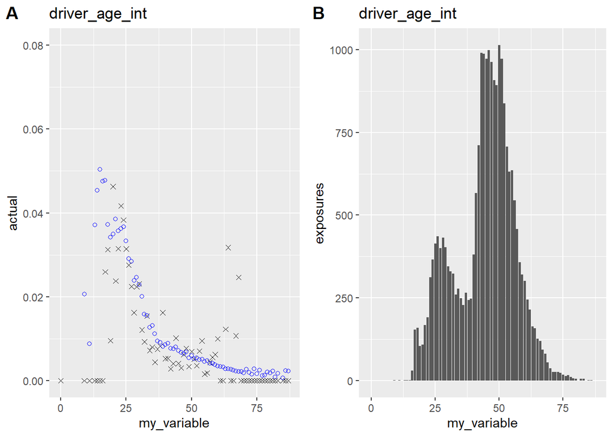

```r
dataOhlsson_test <- dataOhlsson_test %>%
  mutate(parish_bin_fctr = case_when(as.double(parish_fctr)>4 ~ "5-7",
                                  as.double(parish_fctr)<5 ~ as.character(parish_fctr))) %>%
  mutate(parish_bin_fctr = factor(parish_bin_fctr, levels = c("4","1","2","3","5-7"))) %>%
  mutate(ev_ratio_bin_fctr = as.numeric(ev_ratio_int)) %>%
  mutate(ev_ratio_bin_fctr = case_when(ev_ratio_bin_fctr < 5 ~ "1-4",
                                    ev_ratio_bin_fctr == 5 ~ "5",
                                    ev_ratio_bin_fctr > 5 ~ "6-7")) %>%
  mutate(ev_ratio_bin_fctr = factor(ev_ratio_bin_fctr, levels = c("1-4","5","6-7"))) %>%
  mutate(vehicle_age_cap_int = if_else(vehicle_age_int > 25, as.double(25), as.double(vehicle_age_int))) %>%
  mutate(transform_veh_age_x1 = log(vehicle_age_cap_int+1) - log(15+1))

dataOhlsson_test$glm_int_fitted_values <- predict(glm_interaction,
                                                  newdata = dataOhlsson_test,
                                                  type = "response")

one_way_plot <- function(varname){

  summary <- dataOhlsson_test %>%
    group_by_at(varname) %>%
    summarize(actual = sum(claims)/sum(exposures),
              fitted = sum(glm_int_fitted_values)/sum(exposures),
              exposures = sum(exposures),
              .groups = 'drop') %>%
    ungroup()
  names(summary)[1]<-"my_variable"

  actual_fitted_plot <- ggplot(data = summary) +
    geom_point(aes(x = my_variable, y = actual),col = "black",shape=4) +
    geom_point(aes(x = my_variable, y = fitted),col = "blue",shape = 1) +
    ggtitle(varname) +
    ylim(c(0,.08))

  expo_plot <- ggplot(data = summary) +
    geom_col(aes(x = my_variable, y = exposures)) +
    ggtitle(varname)

  plot_grid(actual_fitted_plot, expo_plot, labels = "AUTO")
}

one_way_plot("driver_age_int")
```

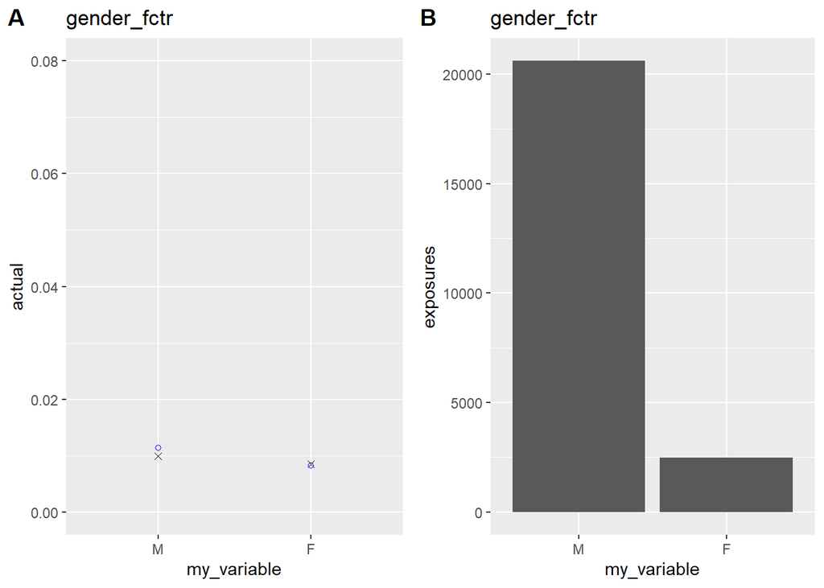

```r
one_way_plot("gender_fctr")
```

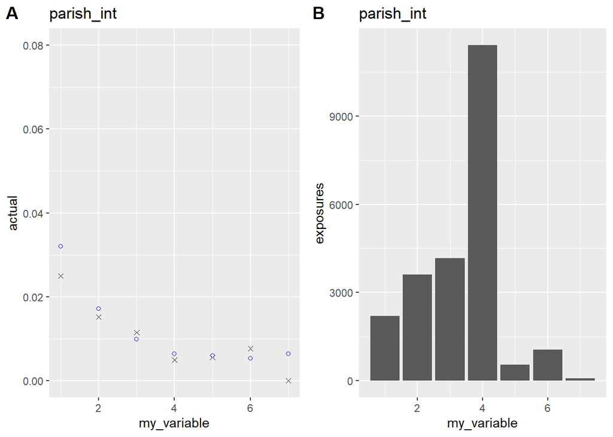

```r
one_way_plot("parish_int")
```

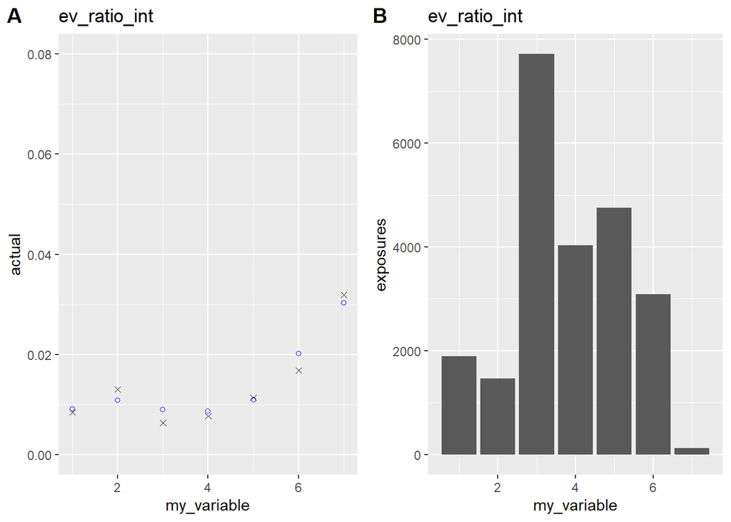

```r
one_way_plot("ev_ratio_int")
```

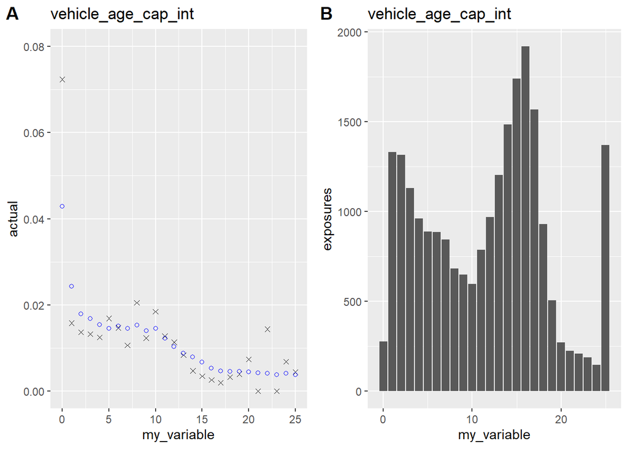

```r
one_way_plot("vehicle_age_cap_int")
```

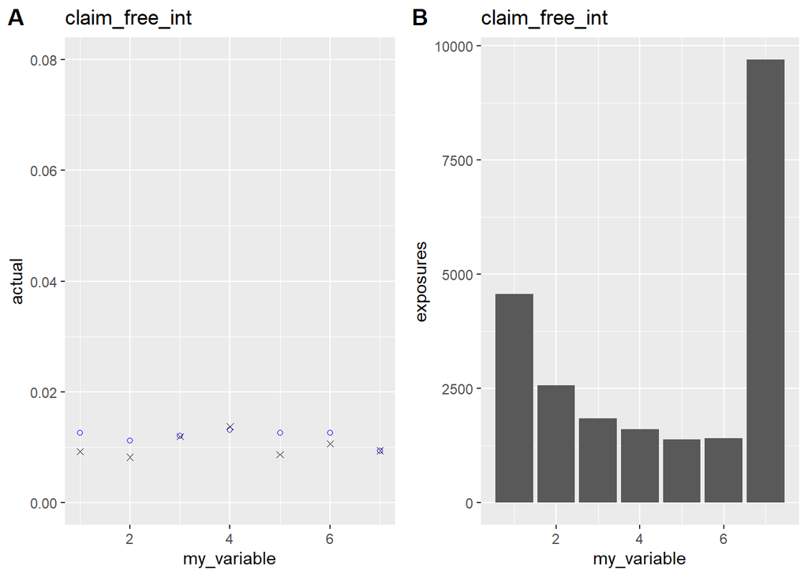

```r
one_way_plot("claim_free_int")
```

## Comparing Models

I create a couple more models for comparison purposes.

### Underfit model

```r
dataOhlsson_train <- dataOhlsson_train %>%
  mutate(under25_fctr = if_else(driver_age_int < 25, "Under 25", "25 and Over")) %>%
  mutate(under25_fctr = factor(under25_fctr, levels = c("25 and Over","Under 25")))

glm_underfit <- glm(claims ~ under25_fctr,
                    family = poisson(link = "log"),
                    data = dataOhlsson_train,
                    offset = log(exposures))

dataOhlsson_train$glm_underfit_fitted_values <- glm_underfit$fitted.values
```

### Overfit model

This is a model where there is a beta parameter for every non-base level. Every rating variable is treated like a categorical variable.

```r
dataOhlsson_train <- dataOhlsson_train %>%
  mutate(driver_age_int_fctr = factor(driver_age_int, levels = c(50,0:49,51:100)),
         ev_ratio_int_fctr = factor(ev_ratio_int, levels = c(3,1,2,4,5,6,7)),
         vehicle_age_int_fctr = factor(vehicle_age_int, levels = c(15,0:14,16:100)))

glm_overfit <- glm(claims ~ driver_age_int_fctr + gender_fctr + parish_fctr +
                     ev_ratio_int_fctr + vehicle_age_int_fctr + claim_free_fctr,
                   family = poisson(link = "log"),
                   data = dataOhlsson_train,
                   offset = log(exposures))
dataOhlsson_train$glm_overfit_fitted_values <- glm_overfit$fitted.values
```

### Deviance checks on the training data

```r
glm_simple$null.deviance
```

```
## [1] 4433.494
```

```r
glm_underfit$deviance
```

```
## [1] 4316.028
```

```r
glm_simple$deviance
```

```
## [1] 3816.622
```

```r
glm_interaction$deviance
```

```
## [1] 3802.002
```

```r
glm_overfit$deviance
```

```
## [1] 3678.493
```

```r
glm_underfit$aic
```

```
## [1] 5226.302
```

```r
glm_simple$aic
```

```
## [1] 4742.896
```

```r
glm_interaction$aic
```

```
## [1] 4730.276
```

```r
glm_overfit$aic
```

```
## [1] 4942.767
```

### Deviance checks on the Test Data

# Apply same transformations to test data

```r
dataOhlsson_test <- dataOhlsson_test %>%
  filter(driver_age_int != 0 & driver_age_int != 87) %>%
  filter(!(vehicle_age_int %in% c(72,76,77,82,83)))

dataOhlsson_test <- dataOhlsson_test %>%
  mutate(under25_fctr = if_else(driver_age_int < 25, "Under 25", "25 and Over")) %>%
  mutate(under25_fctr = factor(under25_fctr, levels = c("25 and Over","Under 25"))) %>%
  mutate(driver_age_int_fctr = factor(driver_age_int, levels = c(50,0:49,51:100)),
         ev_ratio_int_fctr = factor(ev_ratio_int, levels = c(3,1,2,4,5,6,7)),
         vehicle_age_int_fctr = factor(vehicle_age_int, levels = c(15,0:14,16:100)))

dataOhlsson_test$glm_underfit_fitted_values <- predict(glm_underfit, newdata = dataOhlsson_test, type = "response")
dataOhlsson_test$glm_overfit_fitted_values <- predict(glm_overfit, newdata = dataOhlsson_test, type = "response")

# Deviance
dataOhlsson_test <- dataOhlsson_test %>%
  mutate(underfit_diff_squared = (claims - glm_underfit_fitted_values)^2,
         int_diff_squared = (claims - glm_int_fitted_values)^2,
         overfit_diff_squared = (claims - glm_overfit_fitted_values)^2)

sum(dataOhlsson_test$underfit_diff_squared)
```

```
## [1] 238.8381
```

```r
sum(dataOhlsson_test$int_diff_squared)
```

```
## [1] 235.8696
```

```r
sum(dataOhlsson_test$overfit_diff_squared)
```

```
## [1] 236.2619
```